# Day twelve - 7/25

Marcus W. Beck, beck.marcus@epa.gov

### Spatial analysis in R - interpolation and raster extract

```r
knitr::opts_chunk$set(echo = TRUE, warning = FALSE, message = FALSE)
options(stringsAsFactors = FALSE)

library(tidyr)
library(rgdal)
library(rgeos)
library(raster)
library(gstat)
library(ncdf4)
library(ggmap)
```

Load some data:

```r
# get data from figshare
# download.file('https://figshare.com/articles/OSS_data_-_2017_monday/5136289', destfile = './tuesdata.zip')
unzip('tuesdata.zip', exdir = './GISdata')
```

#### Extract from a raster

Reproject, crop raster by study area:

```r
# import data
study_area <- readOGR('GISdata/study-area/study-area.shp')
climate <- raster('GISdata/climate/air.sfc.mon.mean.nc')
crs(study_area)
```

```
## CRS arguments:
##  +proj=longlat +datum=WGS84 +no_defs +ellps=WGS84 +towgs84=0,0,0
```

```r
crs(climate)
```

```
## CRS arguments:
##  +proj=lcc +x_0=5632642.22547 +y_0=4612545.65137 +lat_0=50
## +lon_0=-107 +lat_1=50 +lat_2=50 +ellps=WGS84
```

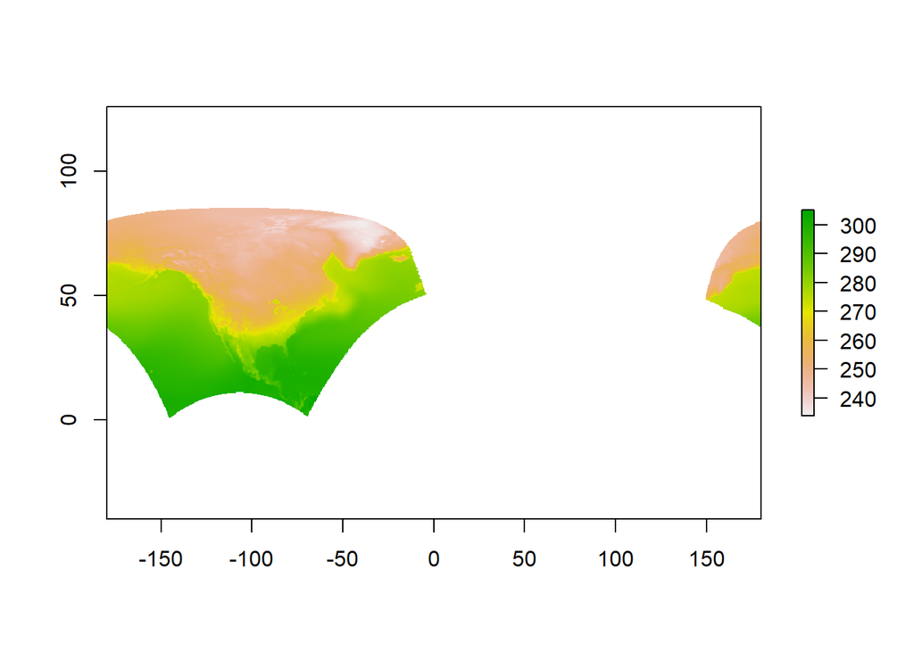

```r
# reproject raster to crs of vector
climate_geog <-  projectRaster(climate, crs = crs(study_area))
plot(climate_geog)
```

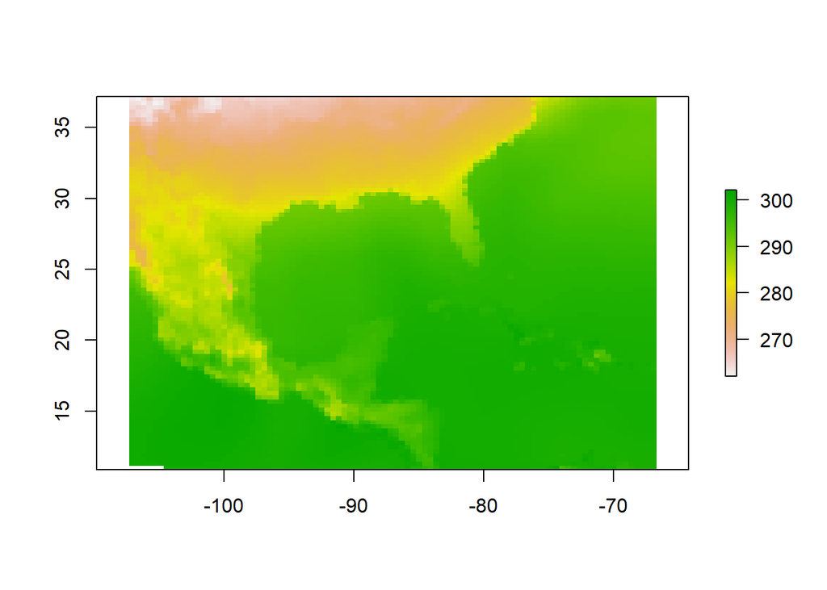

```r
# crop raster by vector
climate_geog_cr <- crop(climate_geog, study_area)
plot(climate_geog_cr)
```

Import point data to extract:

```r
slv <- readOGR('GISdata/tues-data/sea_level_2000.shp')
crs(slv)
```

```
## CRS arguments:
##  +proj=longlat +datum=WGS84 +no_defs +ellps=WGS84 +towgs84=0,0,0
```

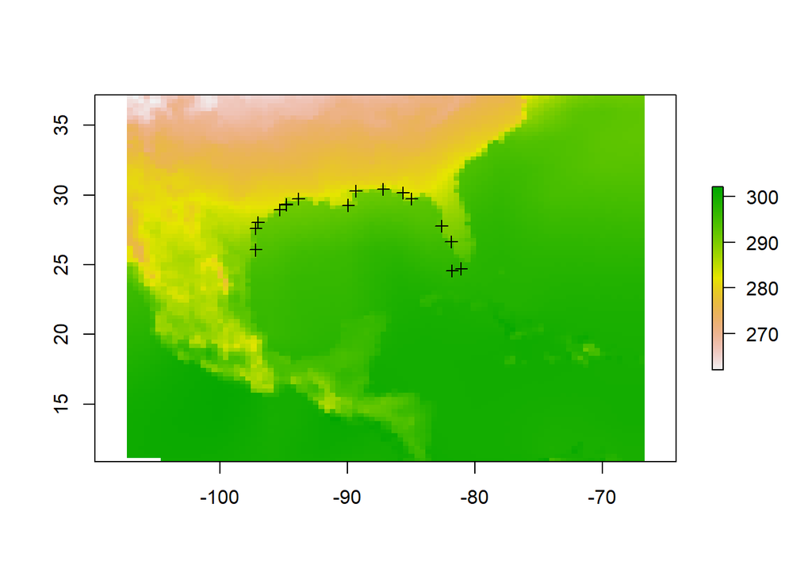

```r
plot(climate_geog_cr)
plot(slv, add = TRUE)
```

Extract climate raster values based on locations in slv

```r
# extract using buffer, not just 1:1 location, summarize w/ mean
# export as a spatial points dataframe, sp = TRUE
climate_mean <- raster::extract(climate_geog_cr,
                                slv,
                                buffer = 0.5,
                                fun = mean,
                                sp = TRUE
                                )
class(climate_mean)
```

```
## [1] "SpatialPointsDataFrame"
## attr(,"package")
## [1] "sp"
```

```r
# get data by slot
climate_df <- climate_mean@data

# get data by indexing (even though it's not a data frame)
climate_mean$year
```

```
##  [1] 2000 2000 2000 2000 2000 2000 2000 2000 2000 2000 2000 2000 2000 2000
## [15] 2000 2000
```

Make a plot:

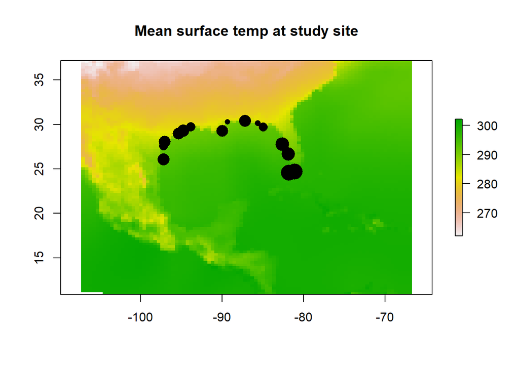

```r
plot(climate_geog_cr, main = 'Mean surface temp at study site')
plot(climate_mean,
     add = TRUE,
     pch = 16,
     cex = scales::rescale(climate_mean$Monthly.air.temperature.at.Surface, to = c(1, 3))
     )
```

Write to file:

```r
writeOGR(climate_mean,
         layer = 'climate_mean', # file name
         dsn = 'GISdata/tues-data', # path
         driver = 'ESRI Shapefile',
         overwrite_layer = TRUE
         )
```

### Creating raster data and interpolation

[general overview](http://neondataskills.org/spatial-data/spatial-interpolation-basics)

Creating raster - gridding (just putting a grid over points, grid cells w/o a point are NA), interpolation (deterministic or probabilistic), triangular irregular network (TIN)

We are going to make a raster out of this:

```r
sea_level_2000 <- read.csv('GISdata/tues-data/sea_lev_2000.csv')
str(sea_level_2000)
```

```
## 'data.frame':    20 obs. of  12 variables:
##  $ X.1       : int  1 2 3 4 5 6 7 8 9 10 ...
##  $ year      : int  2000 2000 2000 2000 2000 2000 2000 2000 2000 2000 ...
##  $ elev_mm   : int  7133 7085 6989 7079 7300 7012 7021 7138 6983 NA ...
##  $ N         : chr  "N" "N" "N" "N" ...
##  $ X         : int  0 0 0 0 0 0 0 0 0 0 ...
##  $ station_id: int  497 538 725 828 161 1835 1903 526 1884 1156 ...
##  $ lat       : num  26.1 28 28.9 29.3 29.3 ...
##  $ long      : num  -97.2 -97 -95.3 -94.8 -94.8 ...
##  $ name      : chr  " PORT ISABEL                             " " ROCKPORT                                " " FREEPORT                                " " GALVESTON I, PLEASURE PIER, TX          " ...
##  $ coast     : int  940 940 940 940 940 940 940 940 940 940 ...
##  $ coast_num : int  1 5 6 7 8 10 15 21 32 37 ...
##  $ C         : chr  " N" " N" " N" " N" ...
```

```r
sea_level_2000$elev_mm
```

```
##  [1] 7133 7085 6989 7079 7300 7012 7021 7138 6983   NA 7064 6959 6901   NA
## [15]   NA 7138 7015   NA 7211 7110
```

```r
# interpolation fails with NA values
# remove them
sea_level_2000 <- sea_level_2000 %>%
  drop_na(elev_mm)
```

Create the spatial object:

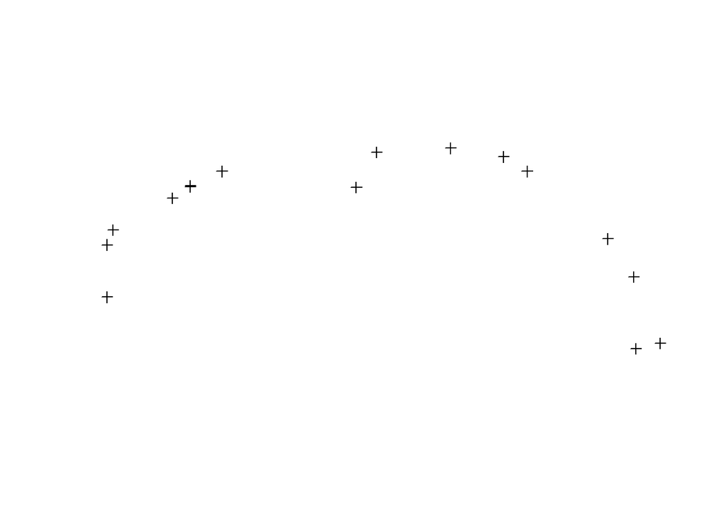

```r
# create spatial points
sl <- sea_level_2000
coordinates(sl) <- ~ long + lat
plot(sl)
```

Now we create an empty grid to interpolate the spatial object:

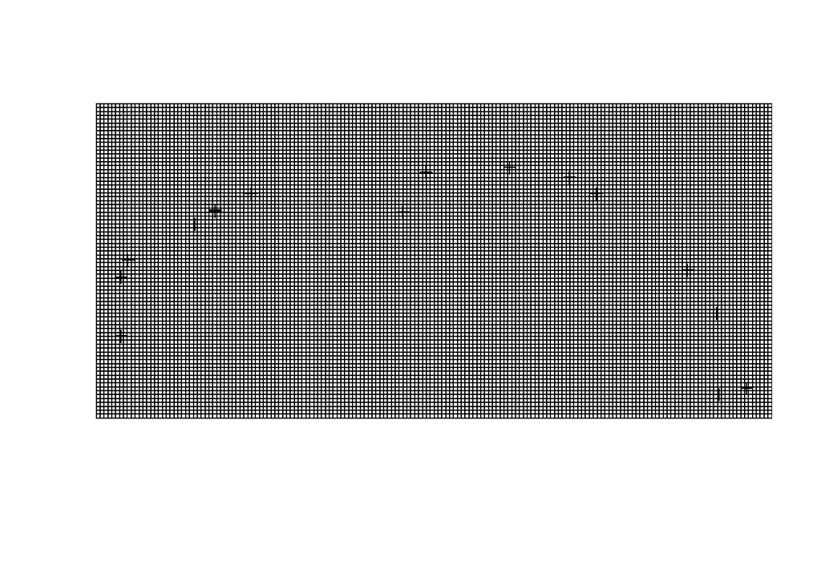

```r
long <- seq(-99, -80, by = .1)
lat <- seq(24, 32, by = .1)
grd <- crossing(long, lat)

# convert grid to matrix, then spatial pixels data frame
coordinates(grd) <- ~long + lat # spatial points
gridded(grd) <- TRUE # make a raster

# plot
plot(sl)
plot(grd, add = T)
```

IDW interpolation:

```r
# two parameters to consider
# radius - maximum distance beyond which not to interpolate beyond each point
# power - how much it weights points by distance, e.g., weighting points higher that are farther away makes a smoother surface (higher power)
idw_pow1 <- idw(formula = elev_mm ~ 1,
                locations = sl, # data used for interpolation
                newdata = grd, # new data to interpolate
                idp = 1, # power
                maxdist = 100
                )
```

```
## [inverse distance weighted interpolation]
```

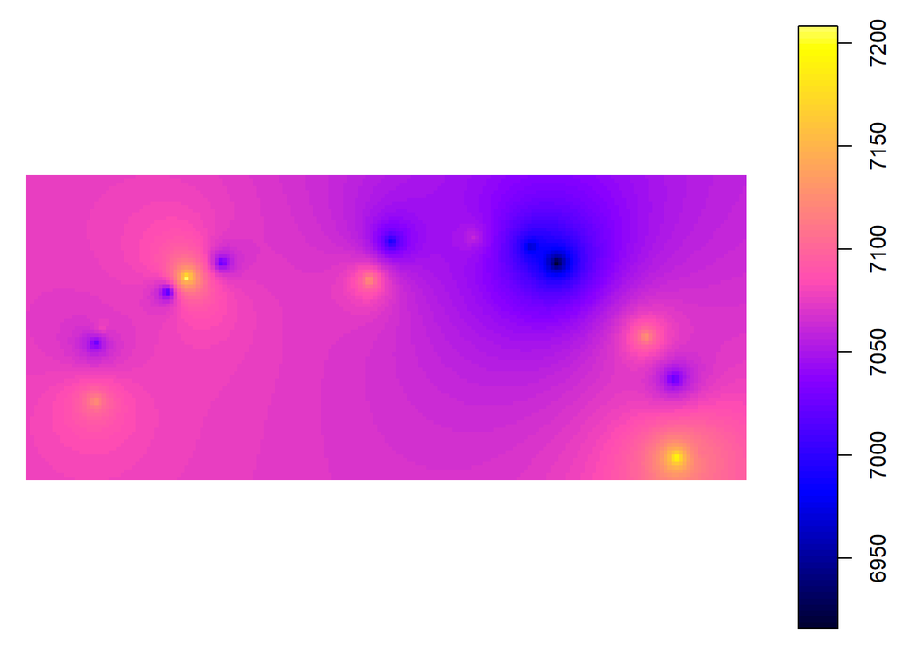

```r
plot(idw_pow1)
```

## Reading netcdf and other open data formats - hierarchical

[info from NEON](https://support.hdfgroup.org/HDF5/)

[Bryce’s link](http://brycemecum.com/2014/02/18/working-with-netcdf-files-in-r.html)

HDF - hierarchical data format, they store different types of data. Embedded metadata.

[HDFview](https://support.hdfgroup.org/HDF5/) - a lightweight Java application for viewing structure of HDF files.

CF conventions - tagging of metadata for processing with other software.

NetCDF is a wrapper to HDF5.

Can store images, text, etc.

Different from a database? HDF4, NetCDF are similar but archivable. Text file access/speed work better with databases but it’s not a place to archive.

ncdump - program used by NCEAS for getting metadata from netcdf.